# **Title:** Impact of Environmental and Weather Conditions on NFL Athletic Performance

**Group Members:** Jon Reed and Ian Kreger

**Project Goal:** The goal of this project is to investigate and determine the impact of environmental and weather conditions on athletic performance in the NFL based on betting odds and weather data from 2000-2020.

# **Description of Datasets:**

**Dataset 1:** This Kaggle dataset contains comprehensive weather data for NFL games 2000 - 2020 from MeteoStat and Weather Underground. This dataset in conjunction with Project Dataset 2 will be the data we use to analyze the influence of weather conditions on athletic performance in the NFL. It compromises 3 primary data tables: (games_2.csv, games_weather.csv, and stadium_coordinates.csv).

• games_2.csv: This table catalogs individual NFL games from 2000-2020, each represented by a unique game_id. For each game, it details the season and the stadium where it took place. This information is important for correlating specific games with corresponding weather data.

•games_weather.csv: This table provides the weather observations associated with each game, linked by their game_id. It includes important weather parameters such as temperature, dew point, humidity, precipitation, and wind speed. These key weather matrics will enable an in-depth analysis of how specific weather conditions may have impacted game outcomes and player performances.

•stadium_coordinates.csv: This table provides structural information about NFL stadiums. For each stadium, it specifies the roof type which is essential for accurately mapping the weather exposure during games.

Using this selected dataset, we can explore future research questions such as: “Do teams with indoor stadiums or certain roof types perform more consistently in adverse weather conditions?”, “Which stadiums experience the most extreme weather variations, and does this create a meaningful home-field advantage?”, “Which teams have the most warm-weather games?”, “Which teams have the most cold-weather games?” and more.

**Dataset 2:** This second dataset, games.csv, located at Git Hub compiles comprehensive NFL game data for analysis and research. Each row represents a single game with a unique game_id and includes several key variables for analyzing the impact of various environmental/weather factors on NFL game outcomes. The inclusion of variables like temperature, wind speed, roof type, and playing surface allows for an in-depth exploration of environmental influences on athletic performance. Additionally, betting-related variables such as spread_line and total_line provide insights into pre-game expectations versus actual results. Using this dataset, we can explore research questions such as: “How do different weather conditions (temperature, wind speed) correlate with game outcomes and pre-game betting odds?”, “How does wind speed affect passing versus rushing performance in NFL games?”, “Do teams playing on artificial turf perform differently in adverse weather conditions compared to those playing on grass?”, “Are games played in domed stadiums more likely to meet or exceed betting expectations compared to those played in open-air stadiums?”, and more.

```python
import pandas as pd
import numpy as np
import matplotlib.pyplot as plt
pd.options.mode.copy_on_write = True
np.random.seed(1)
```

```python
from google.colab import drive
drive.mount('/content/drive')
```

```python
%%shell
#jupyter nbconvert --to html /content/drive/MyDrive/ColabNotebooks/Milestone 1.ipynb
```

**Dataset Documetation:** games_weather.csv, stadium_coordinates.csv, games2.csv were found on kaggle.com. The data was collected from Meteostat and Weather Underground. The data and the file descriptions can be found at https://www.kaggle.com/datasets/tombliss/weather-data/data

```python
df_weather = pd.read_csv('/content/drive/My Drive/games_weather.csv')
df_weather = df_weather[["game_id", "Source", "TimeMeasure", "Temperature", "DewPoint",
                   "Humidity", "Precipitation", "WindSpeed", "WindDirection", "Pressure"]].dropna()
df_weather.head()
```

|  | game_id | Source | TimeMeasure | Temperature | DewPoint | Humidity | Precipitation | WindSpeed | WindDirection | Pressure |
| --- | --- | --- | --- | --- | --- | --- | --- | --- | --- | --- |
| 0 | 2000090300 | Meteostat | 9/3/2000 12:00 | 80.96 | 73.04 | 77.0 | 0.000 | 3.36 | 200.0 | 29.8902 |
| 1 | 2000090300 | Meteostat | 9/3/2000 13:00 | 80.96 | 73.04 | 77.0 | 0.000 | 5.84 | 300.0 | 29.8784 |
| 2 | 2000090300 | Meteostat | 9/3/2000 14:00 | 82.94 | 73.04 | 72.0 | 0.000 | 5.84 | 260.0 | 29.8696 |
| 3 | 2000090300 | Meteostat | 9/3/2000 15:00 | 80.06 | 74.12 | 82.0 | 0.000 | 3.36 | 180.0 | 29.8578 |
| 4 | 2000090300 | Meteostat | 9/3/2000 16:00 | 75.02 | 75.02 | 100.0 | 0.728 | 4.72 | 280.0 | 29.8519 |

```python
df_stadium = pd.read_csv('/content/drive/My Drive/stadium_coordinates.csv')
df_stadium = df_stadium[["StadiumName", "RoofType"]].dropna()
df_stadium.columns = ["stadium_name", "roof_type"]
df_stadium = df_stadium.melt(
    id_vars=["stadium_name"],
    value_vars=["roof_type"],
    var_name="stadium_property",
    value_name="value"
)
df_stadium.head()
```

|  | stadium_name | stadium_property | value |
| --- | --- | --- | --- |
| 0 | Alamodome | roof_type | Indoor |
| 1 | Allegiant Stadium | roof_type | Indoor |
| 2 | Arrowhead Stadium | roof_type | Outdoor |
| 3 | AT&T Stadium | roof_type | Retractable |
| 4 | Bank of America Stadium | roof_type | Outdoor |

```python
df_games_2 = pd.read_csv('/content/drive/My Drive/games2.csv')
df_games_2 = df_games_2[["game_id", "Season", "StadiumName"]].dropna()
df_games_2.columns = ["game_id", "season", "stadium_name"]
df_games_2["season"] = df_games_2["season"].astype(int)
df_games_2.head()
```

|  | game_id | season | stadium_name |
| --- | --- | --- | --- |
| 0 | 2000090300 | 2000 | Giants Stadium |
| 1 | 2000090301 | 2000 | Three Rivers Stadium |
| 2 | 2000090302 | 2000 | FedExField |
| 3 | 2000090303 | 2000 | U.S. Bank Stadium |
| 4 | 2000090304 | 2000 | Mercedes-Benz Superdome |

**Dataset Documentation:** games.csv was found on github at https://github.com/nflverse/nfldata/blob/master/data/games.csv?plain=1

```python
df_games = pd.read_csv('/content/drive/My Drive/games.csv')
df_games = df_games[[
    "game_id", "season", "game_type", "week", "weekday", "away_team", "away_score", "home_team", "home_score",
    "location", "result", "total", "overtime", "away_moneyline", "home_moneyline",
    "spread_line", "away_spread_odds", "home_spread_odds", "total_line",
    "under_odds", "over_odds", "div_game", "surface", "temp", "wind",
    "away_qb_name", "home_qb_name",]]
df_games.fillna({
    "location": "Unknown",
    "result": "Unknown",
    "total": -10000,
    "overtime": "Unknown",
    "away_moneyline": -10000,
    "home_moneyline": -10000,
    "spread_line": -10000,
    "away_spread_odds": -10000,
    "home_spread_odds": -10000,
    "total_line": -10000,
    "under_odds": -10000,
    "over_odds": -10000,
    "div_game": "Unknown",
    "surface": "Unknown",
    "temp": -10000,
    "wind": -10000,
    "away_qb_name": "Unknown",
    "home_qb_name": "Unknown"
}, inplace=True)
df_games.head()
```

|  | game_id | season | game_type | week | weekday | away_team | away_score | home_team | home_score | location | ... | home_spread_odds | total_line | under_odds | over_odds | div_game | surface | temp | wind | away_qb_name | home_qb_name |
| --- | --- | --- | --- | --- | --- | --- | --- | --- | --- | --- | --- | --- | --- | --- | --- | --- | --- | --- | --- | --- | --- |
| 0 | 1999_01_MIN_ATL | 1999 | REG | 1 | Sunday | MIN | 17 | ATL | 14 | Home | ... | -10000.0 | 49.0 | -10000.0 | -10000.0 | 0 | astroturf | -10000.0 | -10000.0 | Randall Cunningham | Chris Chandler |
| 1 | 1999_01_KC_CHI | 1999 | REG | 1 | Sunday | KC | 17 | CHI | 20 | Home | ... | -10000.0 | 38.0 | -10000.0 | -10000.0 | 0 | grass | 80.0 | 12.0 | Elvis Grbac | Shane Matthews |
| 2 | 1999_01_PIT_CLE | 1999 | REG | 1 | Sunday | PIT | 43 | CLE | 0 | Home | ... | -10000.0 | 37.0 | -10000.0 | -10000.0 | 1 | grass | 78.0 | 12.0 | Kordell Stewart | Ty Detmer |
| 3 | 1999_01_OAK_GB | 1999 | REG | 1 | Sunday | OAK | 24 | GB | 28 | Home | ... | -10000.0 | 43.0 | -10000.0 | -10000.0 | 0 | grass | 67.0 | 10.0 | Rich Gannon | Brett Favre |
| 4 | 1999_01_BUF_IND | 1999 | REG | 1 | Sunday | BUF | 14 | IND | 31 | Home | ... | -10000.0 | 45.5 | -10000.0 | -10000.0 | 1 | astroturf | -10000.0 | -10000.0 | Doug Flutie | Peyton Manning |

5 rows × 27 columns

## Summary Statistics:

```python
wind_bins = [0, 5, 10, 15, 20, 50]  # Wind speed categories
wind_labels = ["0-5 mph", "5-10 mph", "10-15 mph", "15-20 mph", ">20 mph"]
df_games["wind_category"] = pd.cut(df_games["wind"], bins=wind_bins, labels=wind_labels)
wind_avg_points = df_games.groupby("wind_category")["total"].mean()
print("\nAverage Total Points by Wind Speed:\n", wind_avg_points)
```

```
Average Total Points by Wind Speed:
 wind_category
0-5 mph      44.625712
5-10 mph     43.505780
10-15 mph    42.018809
15-20 mph    40.913793
>20 mph      38.724138
Name: total, dtype: float64
```

**Justification:** This summary statistic can assess the impact of higher and lower wind speed conditions on scoring and offensive production in NFL games. Higher wind speeds may disrupt passing plays and field goal attempts, potentially leading to lower-scoring games. Conversely, low wind speeds might have little to no effect on the total points scored.

```python
temp_bins = [-10, 32, 50, 70, 90, 120]
temp_labels = ["<32°F", "32-50°F", "50-70°F", "70-90°F", ">90°F"]
df_games["temp_category"] = pd.cut(df_games["temp"], bins=temp_bins, labels=temp_labels)
temp_avg_points = df_games.groupby("temp_category")["total"].mean()
print("Average Total Points by Temperature:\n", temp_avg_points)
```

```
Average Total Points by Temperature:
 temp_category
<32°F      43.350685
32-50°F    43.097331
50-70°F    43.555450
70-90°F    42.738325
>90°F      42.500000
Name: total, dtype: float64
```

**Justification:** This summary statistic helps determine whether extreme temperatures (hot or cold) impact scoring in NFL games. If total points significantly decrease in very hot or cold conditions, it could suggest that weather impacts player performance, play-calling, or fatigue.

```python
valid_temp_games = df_games[(df_games["temp"] > -10000) & (df_games["temp"] < 120)]

cold_games = valid_temp_games[valid_temp_games["temp"] < 32].copy()
hot_games = valid_temp_games[valid_temp_games["temp"] > 90].copy()

cold_games["home_win"] = cold_games["home_score"] > cold_games["away_score"]
hot_games["home_win"] = hot_games["home_score"] > hot_games["away_score"]

home_win_rate_cold = cold_games["home_win"].mean()
home_win_rate_hot = hot_games["home_win"].mean()

print("\nHome Win Rate in Cold Games (<32°F): {:.2f}%".format(home_win_rate_cold * 100))
print("Home Win Rate in Hot Games (>90°F): {:.2f}%".format(home_win_rate_hot * 100))
```

```
Home Win Rate in Cold Games (<32°F): 62.42%
Home Win Rate in Hot Games (>90°F): 44.12%
```

**Justification:** This summary statistic will compare win rates of home vs away teams under different temperature conditions to assess whether weather disproportionately benefits or hinders specific teams. Home-field advantage is a very real phenomenon and may be influenced by extreme temperatures. Teams accustomed to warm weather (Miami Dolphins) may struggle in freezing conditions, and vice-versa.

```python
surface_avg_points = df_games.groupby("surface")["total"].mean().sort_values()
print("\nAverage Total Points by Playing Surface:\n", surface_avg_points)
```

```
Average Total Points by Playing Surface:
 surface
astroplay     39.898305
dessograss    43.278689
grass         43.284979
grass         43.344086
astroturf     44.922269
fieldturf     45.315728
Unknown       45.558140
sportturf     46.426282
a_turf        46.772277
matrixturf    48.548718
Name: total, dtype: float64
```

**Justification:** This summary statistic helps assess how the type of playing surface can influence the speed of play, traction, and in turn scoring. Natural grass may slow players down in adverse weather conditions as opposed to artificial grass. Understanding how scoring differs on these surfaces can help evaluate the relationship between field conditions and weather on performance/scoring.

## Graphic:

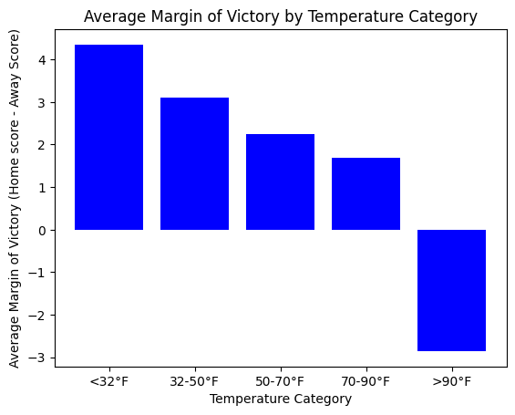

```python
df_games = df_games[(df_games["temp"] > -10000) & (df_games["temp"] < 120) &
                    (df_games["home_score"] >= 0) & (df_games["away_score"] >= 0)]

df_games["margin"] = df_games["home_score"] - df_games["away_score"]

#These were stated earlier, but included for ease of understanding
temp_bins = [-10, 32, 50, 70, 90, 120]
temp_labels = ["<32°F", "32-50°F", "50-70°F", "70-90°F", ">90°F"]

df_games["temp_category"] = pd.cut(df_games["temp"], bins=temp_bins, labels=temp_labels)

avg_margin_by_temp = df_games.groupby("temp_category")["margin"].mean()

plt.bar(avg_margin_by_temp.index, avg_margin_by_temp.values, color='blue')
plt.xlabel("Temperature Category")
plt.ylabel("Average Margin of Victory (Home score - Away Score)")
plt.title("Average Margin of Victory by Temperature Category")
```

**Justification:** This bar graph that bins games by temperature ranges and displays the average margin of victory for each bin would help identify whether temperature influences the competitiveness of NFL games. This visualization can help reveal whether games played under certain temperature ranges tend to have closer or wider margins. If games in extreme temperatures tend to have wider margins, it could indicate that certain teams struggle more in those conditions.